# PI_diabetesPredic

### Anwendung von Machine Learning im Gesundheitswesen

### Vorhersage von Typ-2-Diabetes mit Random Forests und Hyperparameter-Tuning

**Fach:** Modul 12 – *Application of Machine Learning in Health Care*  
**Lehrperson:** DI Dr. Michael Netzer  
**Student:** Luigi Vitulli  
**Universität:** UMIT Tirol **Datum:** 18. Juni 2025

### 1. Einleitung

Der "Pima Indians Diabetes" Datensatz enthält Messdaten von Probandinnen aus einer Pima-Indianer-Gemeinschaft in Arizona (USA). Der Datensatz wurde ursprünglich vom U.S. National Institute of Diabetes and Digestive and Kidney Diseases (NIDDK) erhoben und ist über die Plattform Kaggle öffentlich zugänglich. Ziel dieses Projekts ist es, mithilfe von Supervised Learning – Classification and hyperparameter tuning ein Modell zur Vorhersage des Diabetesrisikos zu entwickeln und zu evaluieren.

**Überblick**

- Ziel: Vorhersage, ob eine Person an Diabetes erkrankt ist (binäre Klassifikation).
- Feature-Überblick: z. B. Anzahl Schwangerschaften, Glukosekonzentration, Blutdruck, BMI, Alter, Hautfaltendicke, Insulinwert und Familiäres Risiko für Typ-2-Diabetes.
- Zielvariable (Target): Outcome (0 = kein Diabetes, 1 = Diabetes)

**Forschungsfrage**

Besteht ein signifikanter Zusammenhang zwischen dem BMI und dem Auftreten von Type-2-Diabetes in dieser Population?

### 2. Datenvorbereitung (Data Preparation and Preprocessing)

```python
#  Blibliotheken importieren, Daten laden und die ersten 5 Zeilen anzeigen.
import matplotlib
import pandas as pd
import numpy as np
import matplotlib.pyplot as plt
import seaborn as sns
file_path = '../data/raw/pima.csv'
df = pd.read_csv(file_path)
df.head()
```

|  | Pregnancies | Glucose | BloodPressure | SkinThickness | Insulin | BMI | DiabetesPedigreeFunction | Age | Outcome |
| --- | --- | --- | --- | --- | --- | --- | --- | --- | --- |
| 0 | 6 | 148 | 72 | 35 | 0 | 33.6 | 0.627 | 50 | 1 |
| 1 | 1 | 85 | 66 | 29 | 0 | 26.6 | 0.351 | 31 | 0 |
| 2 | 8 | 183 | 64 | 0 | 0 | 23.3 | 0.672 | 32 | 1 |
| 3 | 1 | 89 | 66 | 23 | 94 | 28.1 | 0.167 | 21 | 0 |
| 4 | 0 | 137 | 40 | 35 | 168 | 43.1 | 2.288 | 33 | 1 |

```python
# Analyse des Datensatzes
df.info()
df.describe()
```

```
<class 'pandas.core.frame.DataFrame'>
RangeIndex: 768 entries, 0 to 767
Data columns (total 9 columns):
 #   Column                    Non-Null Count  Dtype
---  ------                    --------------  -----
 0   Pregnancies               768 non-null    int64
 1   Glucose                   768 non-null    int64
 2   BloodPressure             768 non-null    int64
 3   SkinThickness             768 non-null    int64
 4   Insulin                   768 non-null    int64
 5   BMI                       768 non-null    float64
 6   DiabetesPedigreeFunction  768 non-null    float64
 7   Age                       768 non-null    int64
 8   Outcome                   768 non-null    int64
dtypes: float64(2), int64(7)
memory usage: 54.1 KB
```

|  | Pregnancies | Glucose | BloodPressure | SkinThickness | Insulin | BMI | DiabetesPedigreeFunction | Age | Outcome |
| --- | --- | --- | --- | --- | --- | --- | --- | --- | --- |
| count | 768.000000 | 768.000000 | 768.000000 | 768.000000 | 768.000000 | 768.000000 | 768.000000 | 768.000000 | 768.000000 |
| mean | 3.845052 | 120.894531 | 69.105469 | 20.536458 | 79.799479 | 31.992578 | 0.471876 | 33.240885 | 0.348958 |
| std | 3.369578 | 31.972618 | 19.355807 | 15.952218 | 115.244002 | 7.884160 | 0.331329 | 11.760232 | 0.476951 |
| min | 0.000000 | 0.000000 | 0.000000 | 0.000000 | 0.000000 | 0.000000 | 0.078000 | 21.000000 | 0.000000 |
| 25% | 1.000000 | 99.000000 | 62.000000 | 0.000000 | 0.000000 | 27.300000 | 0.243750 | 24.000000 | 0.000000 |
| 50% | 3.000000 | 117.000000 | 72.000000 | 23.000000 | 30.500000 | 32.000000 | 0.372500 | 29.000000 | 0.000000 |
| 75% | 6.000000 | 140.250000 | 80.000000 | 32.000000 | 127.250000 | 36.600000 | 0.626250 | 41.000000 | 1.000000 |
| max | 17.000000 | 199.000000 | 122.000000 | 99.000000 | 846.000000 | 67.100000 | 2.420000 | 81.000000 | 1.000000 |

```python
# Nullstellen anzeigen
(df == 0).sum()
```

```
Pregnancies                 111
Glucose                       5
BloodPressure                35
SkinThickness               227
Insulin                     374
BMI                          11
DiabetesPedigreeFunction      0
Age                           0
Outcome                     500
dtype: int64
```

```python
# Nur relevante Spalten mit Nullstellen auswählen
columns_with_invalid_zeros = ['Glucose', 'BloodPressure', 'SkinThickness', 'Insulin', 'BMI']

# Nullstellen mit NaN ersetzen
df[columns_with_invalid_zeros] = df[columns_with_invalid_zeros].replace(0, np.nan)

# Fehlende Werte mit dem Median ersetzen
from sklearn.impute import SimpleImputer
imputer = SimpleImputer(strategy='median')
df[columns_with_invalid_zeros] = imputer.fit_transform(df[columns_with_invalid_zeros])
```

```python
# Statistik prüfen für die Spalten mit Nullstellen
df[columns_with_invalid_zeros].describe()
```

|  | Glucose | BloodPressure | SkinThickness | Insulin | BMI |
| --- | --- | --- | --- | --- | --- |
| count | 768.000000 | 768.000000 | 768.000000 | 768.000000 | 768.000000 |
| mean | 121.656250 | 72.386719 | 29.108073 | 140.671875 | 32.455208 |
| std | 30.438286 | 12.096642 | 8.791221 | 86.383060 | 6.875177 |
| min | 44.000000 | 24.000000 | 7.000000 | 14.000000 | 18.200000 |
| 25% | 99.750000 | 64.000000 | 25.000000 | 121.500000 | 27.500000 |
| 50% | 117.000000 | 72.000000 | 29.000000 | 125.000000 | 32.300000 |
| 75% | 140.250000 | 80.000000 | 32.000000 | 127.250000 | 36.600000 |
| max | 199.000000 | 122.000000 | 99.000000 | 846.000000 | 67.100000 |

### 3. Explorative Datenanalyse (EDA)

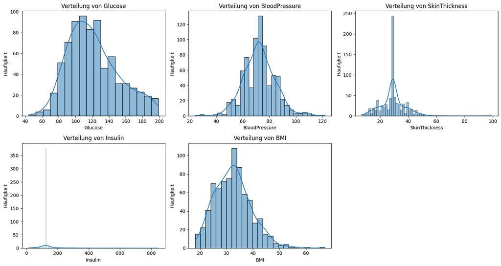

```python
# Histogramme (Verteilung)
cols_to_check = ['Glucose', 'BloodPressure', 'SkinThickness', 'Insulin', 'BMI']

# Größe des Gesamtplots (Breite, Höhe)
plt.figure(figsize=(15, 8))

# Für jede Spalte einen Subplot erstellen
for i, col in enumerate(cols_to_check):
    plt.subplot(2, 3, i + 1)  # 2 Zeilen, 3 Spalten (es gibt 5 Plots)
    sns.histplot(df[col], kde=True)
    plt.title(f"Verteilung von {col}")
    plt.xlabel(col)
    plt.ylabel("Häufigkeit")

plt.tight_layout()  # Sorgt dafür, dass sich die Plots nicht überlappen
plt.show()
```

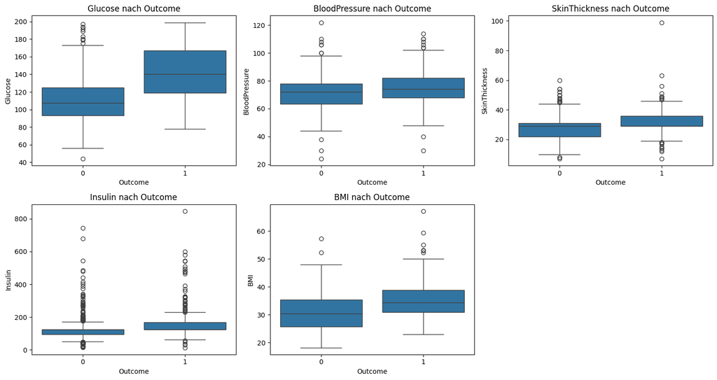

```python
# Boxplots nach Zielvariable Outcome
cols_to_check = ['Glucose', 'BloodPressure', 'SkinThickness', 'Insulin', 'BMI']

plt.figure(figsize=(15, 8))

for i, col in enumerate(cols_to_check):
    plt.subplot(2, 3, i + 1)  # 2 Zeilen, 3 Spalten
    sns.boxplot(x='Outcome', y=col, data=df)
    plt.title(f"{col} nach Outcome")
    plt.xlabel("Outcome")
    plt.ylabel(col)

plt.tight_layout()
plt.show()
```

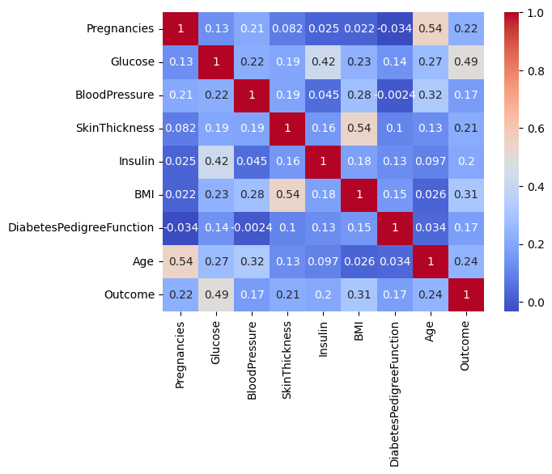

```python
# Korrelationen prüfen
df.corr()
sns.heatmap(df.corr(), annot=True, cmap="coolwarm")
```

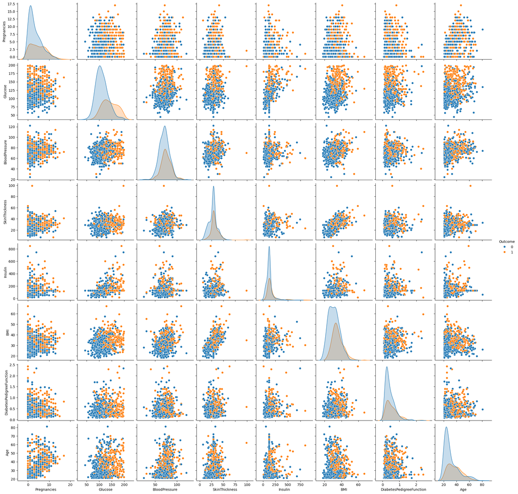

```python
# Pairplot for numerical features
sns.pairplot(data = df.select_dtypes(include='number'), hue = 'Outcome')
plt.show()
```

```python
# Gruppierter Mittelwert
mean_bmi = df.groupby('Outcome')['BMI'].mean()
print(mean_bmi)
```

```
Outcome
0    30.885600
1    35.383582
Name: BMI, dtype: float64
```

```python
# T-Test für den BMI zwischen den Gruppen Outcome 0 und 1
from scipy.stats import ttest_ind

bmi_0 = df[df['Outcome'] == 0]['BMI']
bmi_1 = df[df['Outcome'] == 1]['BMI']

t_stat, p_value = ttest_ind(bmi_0, bmi_1, equal_var=False)  # Welch-Test ist robuster
print(f"T-Wert: {t_stat:.2f}, p-Wert: {p_value:.5f}")
```

```
T-Wert: -9.05, p-Wert: 0.00000
```

### 4. ML-Part

```python
# Daten in Trainings- und Testset aufteilen
from sklearn.model_selection import train_test_split

# Unabhängige Variablen (Features) und Zielvariable (Outcome) trennen
X = df.drop('Outcome', axis=1)
y = df['Outcome']

# Split: 75% Training, 25% Test
X_train, X_test, y_train, y_test = train_test_split(
    X, y,
    test_size=0.25,       # 25% Testdaten
    random_state=42,      # Reproduzierbarkeit
    stratify=y            # optional: für ausgewogene Klassenverteilung
)

# Klassenverteilung im Originaldatensatz
print("Gesamtdaten:")
print(y.value_counts(normalize=True))

# Verteilung im Trainingsdatensatz
print("\nTrainingsdaten:")
print(y_train.value_counts(normalize=True))

# Verteilung im Testdatensatz
print("\nTestdaten:")
print(y_test.value_counts(normalize=True))
```

```
Gesamtdaten:
Outcome
0    0.651042
1    0.348958
Name: proportion, dtype: float64

Trainingsdaten:
Outcome
0    0.651042
1    0.348958
Name: proportion, dtype: float64

Testdaten:
Outcome
0    0.651042
1    0.348958
Name: proportion, dtype: float64
```

```python
# Modelltraining mit Random Forest
from sklearn.ensemble import RandomForestClassifier

# Modell initialisieren
rf = RandomForestClassifier(random_state=42)

# Modell trainieren
rf.fit(X_train, y_train)
```

```
RandomForestClassifier(random_state=42)
```

```python
# Grid-Search: Beispiel mit 10-fold Cross-Validation
from sklearn.ensemble import RandomForestClassifier
from sklearn.model_selection import GridSearchCV

# Define tuning grid
param_grid = {
    'n_estimators': [100, 200],
    'max_depth': [None, 5, 10],
    'max_features': ['sqrt', 'log2']
}

# Set up the GridSearch with 10-fold CV
grid = GridSearchCV(
    estimator=RandomForestClassifier(random_state=42),
    param_grid=param_grid,
    cv=10,
    scoring='roc_auc',  # or 'accuracy', depending on your goal
    n_jobs=-1
)

# Fit to training data
grid.fit(X_train, y_train)

# Best model and parameters
print("Best parameters:", grid.best_params_)
print("Best AUC (CV):", grid.best_score_)
```

```
Best parameters: {'max_depth': 5, 'max_features': 'log2', 'n_estimators': 200}
Best AUC (CV): 0.840948994106889
```

```python
# Nehme das beste Modell aus der Grid-Search
best_rf = grid.best_estimator_
y_pred = best_rf.predict(X_test)
y_proba = best_rf.predict_proba(X_test)[:, 1]
```

```python
# Prüfe die Vorhersagen
print("Erste 10 Vorhersagen (Klasse):", y_pred[:10])
print("Erste 10 Wahrscheinlichkeiten (für Klasse 1):", y_proba[:10])
print("Shape y_pred:", y_pred.shape)
```

```
Erste 10 Vorhersagen (Klasse): [0 0 0 0 1 0 0 0 1 0]
Erste 10 Wahrscheinlichkeiten (für Klasse 1): [0.44192736 0.33224524 0.07055438 0.32655539 0.84564896 0.1048948
 0.4346014  0.15868052 0.65247699 0.030555  ]
Shape y_pred: (192,)
```

```python
# Klassifikationsmetriken ausgeben
from sklearn.metrics import classification_report, confusion_matrix, accuracy_score, roc_auc_score, cohen_kappa_score

print("Confusion Matrix:")
print(confusion_matrix(y_test, y_pred))

print("\nClassification Report:")
print(classification_report(y_test, y_pred))

print("Accuracy:", accuracy_score(y_test, y_pred))
print("ROC AUC:", roc_auc_score(y_test, y_proba))
print("Cohen’s Kappa:", cohen_kappa_score(y_test, y_pred))
```

```
Confusion Matrix:
[[108  17]
 [ 32  35]]

Classification Report:
              precision    recall  f1-score   support

           0       0.77      0.86      0.82       125
           1       0.67      0.52      0.59        67

    accuracy                           0.74       192
   macro avg       0.72      0.69      0.70       192
weighted avg       0.74      0.74      0.74       192

Accuracy: 0.7447916666666666
ROC AUC: 0.8163582089552239
Cohen’s Kappa: 0.4075566750629722
```

```
<sklearn.metrics._plot.roc_curve.RocCurveDisplay at 0x14768c670>
```

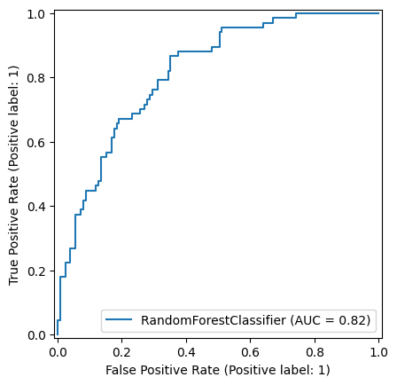

```python
# ROC-Kurve plotten
from sklearn.metrics import RocCurveDisplay
RocCurveDisplay.from_estimator(best_rf, X_test, y_test)
```

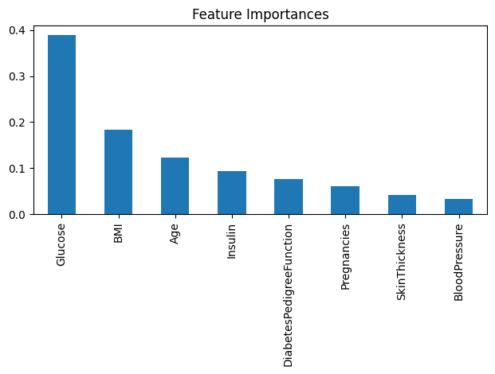

```
Top 3 Feature Importances:
Glucose    0.390016
BMI        0.182773
Age        0.123319
dtype: float64
```

```python
# Feature Importances plotten
importances = pd.Series(best_rf.feature_importances_, index=X.columns)
importances.sort_values(ascending=False).plot(kind='bar', title='Feature Importances')
plt.tight_layout()
plt.show()

# Berechnung wie gehabt
importances = pd.Series(best_rf.feature_importances_, index=X.columns)

# Top 3 extrahieren
top3 = importances.sort_values(ascending=False).head(3)

# Ausgabe in Konsole
print("Top 3 Feature Importances:")
print(top3)
```

### 5. Antwort auf die Forschungsfrage:

*"Besteht ein signifikanter Zusammenhang zwischen dem BMI und dem Auftreten von Typ-2-Diabetes in dieser Population?"*

Ja, die durchgeführte Analyse zeigt, dass ein signifikanter Zusammenhang zwischen dem Body-Mass-Index (BMI) und dem Auftreten von Typ-2-Diabetes in der untersuchten Population von Frauen der Pima-Indianer besteht. Dieser Zusammenhang wurde durch eine Kombination aus statistischer Analyse und Machine-Learning-Verfahren (Random Forest mit Hyperparameter-Tuning) bestätigt

**Deskriptive Analyse und t-Test:** Durchschnittlicher BMI bei Nicht-Diabetikerinnen (Outcome = 0): 30.885600 Durchschnittlicher BMI bei Diabetikerinnen (Outcome = 1): 35.383582 t-Test-Ergebnis: t = -9.05, p = 0.00000

- Der t-Wert von -9.05 zeigt einen deutlichen Unterschied zwischen den Gruppen
- Der p-Wert < 0.00001 ist weit unter dem üblichen Signifikanzniveau von 0.05 → der Unterschied ist hochsignifikant

**Feature (Random Forest):** Im trainierten RandomForestClassifier mit GridSearchCV (10-fold CV) zeigte sich

Top Feature Importances:

1. Glucose → 0.390016
2. BMI → 0.182773
3. Age → 0.123319

BMI ist das zweitwichtigste Merkmal im Modell!

**Modell-Performance auf Testdaten**

| Metrik | Wert |
| --- | --- |
| Accuracy | **0.7448** |
| ROC AUC Score | **0.8164** |
| Cohen’s Kappa | **0.4076** |
| Confusion Matrix | `[[108, 17], [32, 35]]` |

Das Modell zeigt eine gute Trennschärfe, besonders erkennbar an der hohen ROC AUC!

**Fazit:** Der BMI ist sowohl statistisch signifikant als auch maschinell hochrelevant für die Vorhersage von Typ-2-Diabetes in der analysierten Population. Sowohl der signifikante Mittelwertsunterschied (t-Test) als auch die hohe Feature-Wichtigkeit im Random Forest und die solide Modellleistung (ROC AUC = 0.82) bestätigen: *"Ja – es besteht ein signifikanter Zusammenhang zwischen BMI und Diabetesrisiko."*

### 6. Quellen und Referenzen

Dataset: https://www.kaggle.com/datasets/uciml/pima-indians-diabetes-database

Datenerhebende Institution (Herkunft der Primärdaten): https://www.niddk.nih.gov/health-information/diabetes

Quellen: Smith, J. W., Everhart, J. E., Dickson, W. C., Knowler, W. C., & Johannes, R. S. (1988). Using the ADAP learning algorithm to forecast the onset of diabetes mellitus. In Proceedings of the Symposium on Computer Applications and Medical Care (pp. 261–265). IEEE Computer Society Press.

Chellappan, D., & Rajaguru, H. (2025). Generalizability of machine learning models for diabetes detection: A study with Nordic islet transplant and PIMA datasets. Scientific Reports, 15(1), Article 4479. https://doi.org/10.1038/s41598-025-87471-0